[output not shown]

# 1 Background

As a statistical consultant working for a real estate investment firm, your task is to develop a model to predict the selling price of a given home in Ames, Iowa. Your employer hopes to use this information to help assess whether the asking price of a house is higher or lower than the true value of the house. If the home is undervalued, it may be a good investment for the firm.

# 2 Training Data and relevant packages

In order to better assess the quality of the model you will produce, the data have been randomly divided into three separate pieces: a training data set, a testing data set, and a validation data set. For now we will load the training data set, the others will be loaded and used later.

```r
load("ames_train.Rdata")
```

Use the code block below to load any necessary packages

```r
library(BAS)
library(MASS)
library(dplyr)
library(GGally)
library(statsr)
library(ggplot2)
```

```r
# disable scientific notation
options(scipen=999)
```

## 2.1 Part 1 - Exploratory Data Analysis (EDA)

When you first get your data, it’s very tempting to immediately begin fitting models and assessing how they perform. However, before you begin modeling, it’s absolutely essential to explore the structure of the data and the relationships between the variables in the data set.

Do a detailed EDA of the ames_train data set, to learn about the structure of the data and the relationships between the variables in the data set (refer to Introduction to Probability and Data, Week 2, for a reminder about EDA if needed). Your EDA should involve creating and reviewing many plots/graphs and considering the patterns and relationships you see.

After you have explored completely, submit the three graphs/plots that you found most informative during your EDA process, and briefly explain what you learned from each (why you found each informative).

Here’s the plot of the distribution of prices:

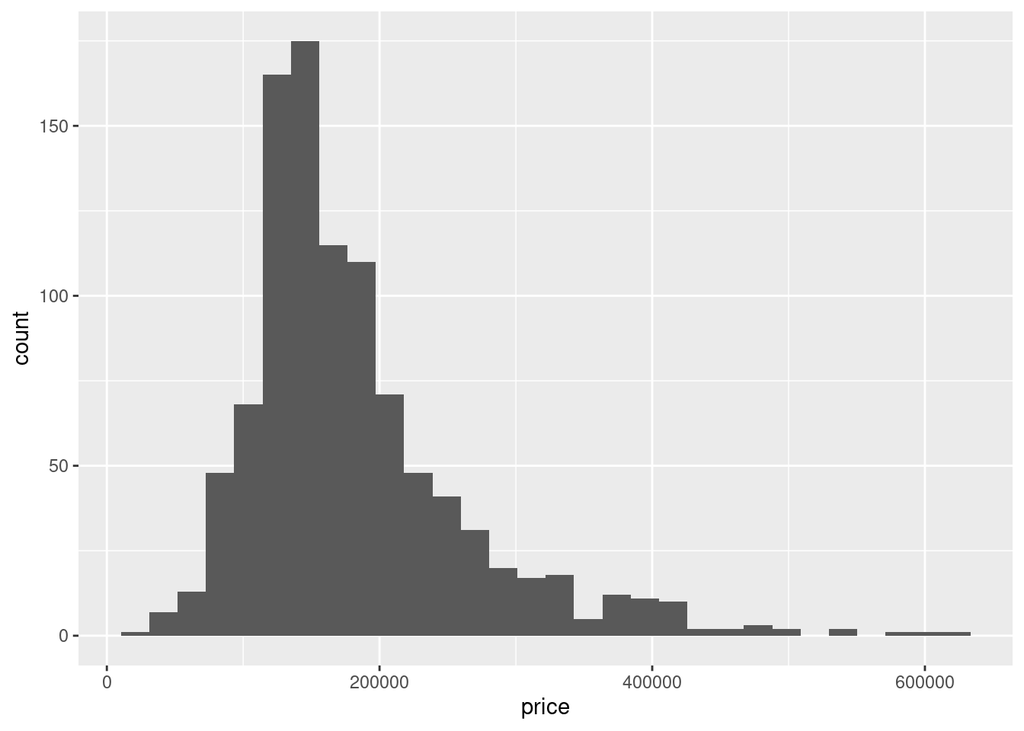

```r
ggplot(data = ames_train, aes(x=price)) + geom_histogram(bins=30)
```

The distribution is right skewed, which makes sense for house prices. Most of the house prices cost less then $400000 with only a few (25) houses above that price.

Next here are the neighborhoods and how they relate to house prices:

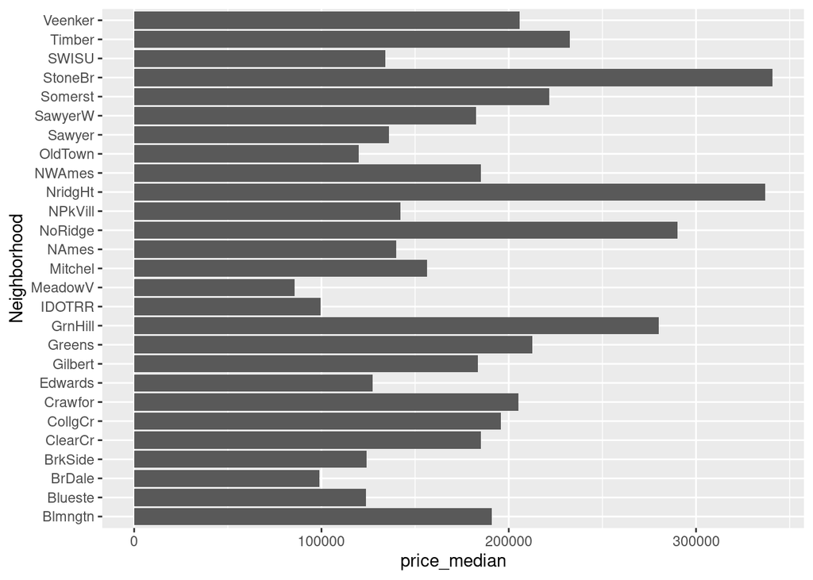

```r
ames_train_neighborhood <- ames_train %>% group_by(Neighborhood) %>% summarise(price_median = median(price))
ggplot(ames_train_neighborhood, aes(Neighborhood, price_median)) + geom_bar(stat="identity") + coord_flip()
```

`StoneBr` and `NridgHt` are two of the most expensive neighborhoods and the cheapest neighborhood is `MeadowV`.

Finally here’s the correlation plot between price and area:

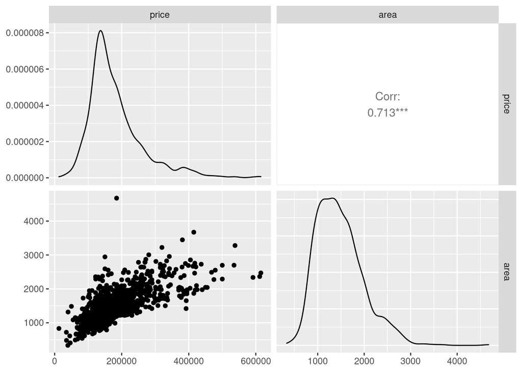

```r
ggpairs(ames_train[, c('price', 'area')])
```

The plot above indicates that there is a somewhat of a linear relationship between area and price (correlation coefficient is high compared to other variables; scatter plot is fairly linear). This makes sense because the bigger the house the more it’s going to cost.

## 2.2 Part 2 - Development and assessment of an initial model, following a semi-guided process of analysis

### 2.2.1 Section 2.1 An Initial Model

In building a model, it is often useful to start by creating a simple, intuitive initial model based on the results of the exploratory data analysis. (Note: The goal at this stage is **not** to identify the “best” possible model but rather to choose a reasonable and understandable starting point. Later you will expand and revise this model to create your final model.

Based on your EDA, select *at most* 10 predictor variables from “ames_train” and create a linear model for `price` (or a transformed version of price) using those variables. Provide the *R code* and the *summary output table* for your model, a *brief justification* for the variables you have chosen, and a *brief discussion* of the model results in context (focused on the variables that appear to be important predictors and how they relate to sales price).

Before doing any modeling I’ll filter out sales conditions that are not normal (reasoning behind this is that other types of sales conditions can have unusually low/high prices and that can throw the model performance off):

```r
ames_train <- ames_train %>% filter(Sale.Condition == "Normal")
```

Below I build the initial model and print out the summary output table:

```r
init_model <- lm(log(price) ~ log(area) + Year.Built + Bedroom.AbvGr + Total.Bsmt.SF + Central.Air + Kitchen.Qual + Garage.Area + Functional, ames_train)

summary(init_model)
```

```
##
## Call:
## lm(formula = log(price) ~ log(area) + Year.Built + Bedroom.AbvGr +
##     Total.Bsmt.SF + Central.Air + Kitchen.Qual + Garage.Area +
##     Functional, data = ames_train)
##
## Residuals:
##      Min       1Q   Median       3Q      Max
## -0.88112 -0.08161  0.00860  0.08486  0.55631
##
## Coefficients:
##                   Estimate  Std. Error t value             Pr(>|t|)
## (Intercept)     2.46467138  0.47570308   5.181     0.00000027800395 ***
## log(area)       0.61750044  0.02439367  25.314 < 0.0000000000000002 ***
## Year.Built      0.00236857  0.00022738  10.417 < 0.0000000000000002 ***
## Bedroom.AbvGr  -0.04734203  0.00821304  -5.764     0.00000001161836 ***
## Total.Bsmt.SF   0.00019080  0.00001577  12.096 < 0.0000000000000002 ***
## Central.AirY    0.22051608  0.02463084   8.953 < 0.0000000000000002 ***
## Kitchen.QualFa -0.25081857  0.04477201  -5.602     0.00000002892973 ***
## Kitchen.QualGd -0.15837751  0.02520303  -6.284     0.00000000053576 ***
## Kitchen.QualPo  0.03816314  0.15273262   0.250             0.802751
## Kitchen.QualTA -0.24754909  0.02746951  -9.012 < 0.0000000000000002 ***
## Garage.Area     0.00021682  0.00003129   6.929     0.00000000000859 ***
## FunctionalMaj2 -0.06155925  0.12468532  -0.494             0.621639
## FunctionalMin1  0.13814129  0.08030219   1.720             0.085762 .
## FunctionalMin2  0.16017502  0.07822910   2.048             0.040927 *
## FunctionalMod   0.12305711  0.08210946   1.499             0.134338
## FunctionalTyp   0.24140800  0.07236418   3.336             0.000888 ***
## ---
## Signif. codes:  0 '***' 0.001 '**' 0.01 '*' 0.05 '.' 0.1 ' ' 1
##
## Residual standard error: 0.1429 on 818 degrees of freedom
## Multiple R-squared:  0.8625, Adjusted R-squared:  0.8599
## F-statistic:   342 on 15 and 818 DF,  p-value: < 0.00000000000000022
```

The reason why I went with these initial variables is that they seemed to have an impact on price when I was doing my EDA.

### 2.2.2 Section 2.2 Model Selection

Now either using `BAS` another stepwise selection procedure choose the “best” model you can, using your initial model as your starting point. Try at least two different model selection methods and compare their results. Do they both arrive at the same model or do they disagree? What do you think this means?

```r
stepAIC(init_model, direction = "backward")
```

```
## Start:  AIC=-3229.16
## log(price) ~ log(area) + Year.Built + Bedroom.AbvGr + Total.Bsmt.SF +
##     Central.Air + Kitchen.Qual + Garage.Area + Functional
##
##                 Df Sum of Sq    RSS     AIC
## <none>                       16.709 -3229.2
## - Functional     5    0.7792 17.489 -3201.1
## - Bedroom.AbvGr  1    0.6787 17.388 -3197.9
## - Garage.Area    1    0.9807 17.690 -3183.6
## - Central.Air    1    1.6373 18.347 -3153.2
## - Kitchen.Qual   4    2.0048 18.714 -3142.7
## - Year.Built     1    2.2165 18.926 -3127.3
## - Total.Bsmt.SF  1    2.9890 19.698 -3093.9
## - log(area)      1   13.0897 29.799 -2748.7
```

```
##
## Call:
## lm(formula = log(price) ~ log(area) + Year.Built + Bedroom.AbvGr +
##     Total.Bsmt.SF + Central.Air + Kitchen.Qual + Garage.Area +
##     Functional, data = ames_train)
##
## Coefficients:
##    (Intercept)       log(area)      Year.Built   Bedroom.AbvGr   Total.Bsmt.SF
##      2.4646714       0.6175004       0.0023686      -0.0473420       0.0001908
##   Central.AirY  Kitchen.QualFa  Kitchen.QualGd  Kitchen.QualPo  Kitchen.QualTA
##      0.2205161      -0.2508186      -0.1583775       0.0381631      -0.2475491
##    Garage.Area  FunctionalMaj2  FunctionalMin1  FunctionalMin2   FunctionalMod
##      0.0002168      -0.0615592       0.1381413       0.1601750       0.1230571
##  FunctionalTyp
##      0.2414080
```

In the code above I’m using a backward elimination model selection technique and it decided that the best model is the original model with all the features. I also tried `forward` selection and it arrived at the same conclusion. If I add a bit more complexity to the model (more features) I’d probably start seeing `backward` and `forward` elimination being more selective about features.

### 2.2.3 Section 2.3 Initial Model Residuals

One way to assess the performance of a model is to examine the model’s residuals. In the space below, create a residual plot for your preferred model from above and use it to assess whether your model appears to fit the data well. Comment on any interesting structure in the residual plot (trend, outliers, etc.) and briefly discuss potential implications it may have for your model and inference / prediction you might produce.

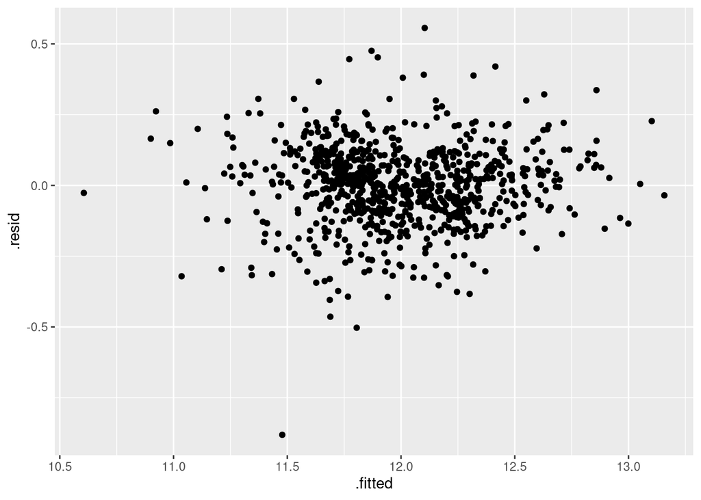

```r
ggplot(init_model, aes(x = .fitted, y = .resid)) + geom_point()
```

The plot above shows that residuals are mostly randomly scattered around 0 which is good but there might be one potential outlier/influential point. That point is at ~11.5 on the X axis and ~-0.8 on y axis. Usually this sort of an outlier can negatively effect model performance by influencing the slope of the regression line.

### 2.2.4 Section 2.4 Initial Model RMSE

You can calculate it directly based on the model output. Be specific about the units of your RMSE (depending on whether you transformed your response variable). The value you report will be more meaningful if it is in the original units (dollars).

```r
predicted_conv_train <- exp(predict(init_model, ames_train))
sqrt(mean((ames_train$price - predicted_conv_train)^2))
```

```
## [1] 25248.45
```

I calculated the RMSE in the code above and got a result of `25248.45`. I converted the scale back to the original units which means RMSE is in dollars. One way to interpret RMSE is as a measure of how close the predicted values are to the actual/observed data points (on average). The lower the RMSE the better. Perfect model (that very likely doesn’t exist and is overfitting) would have an RMSE of 0. Once I calculate RMSE on the test set I’ll have a better idea of how the model performs in the real world.

### 2.2.5 Section 2.5 Overfitting

The process of building a model generally involves starting with an initial model (as you have done above), identifying its shortcomings, and adapting the model accordingly. This process may be repeated several times until the model fits the data reasonably well. However, the model may do well on training data but perform poorly out-of-sample (meaning, on a dataset other than the original training data) because the model is overly-tuned to specifically fit the training data. This is called “overfitting.” To determine whether overfitting is occurring on a model, compare the performance of a model on both in-sample and out-of-sample data sets. To look at performance of your initial model on out-of-sample data, you will use the data set `ames_test`.

```r
load("ames_test.Rdata")
```

Use your model from above to generate predictions for the housing prices in the test data set. Are the predictions significantly more accurate (compared to the actual sales prices) for the training data than the test data? Why or why not? Briefly explain how you determined that (what steps or processes did you use)?

```r
# remove non normal sales conditions
ames_test <- ames_test %>% filter(Sale.Condition == "Normal")
```

```r
# get predictions
preds_test <- predict(init_model, ames_test)

# calculate RMSE
conv_prices <- exp(preds_test)
sqrt(mean((ames_test$price - conv_prices)^2))
```

```
## [1] 26402.39
```

RMSE on the test set is `26402.39`, which is a bit higher then the RMSE on the training dataset. The model is slightly overfitting on the training dataset, but the difference between the RMSEs is not large, thus this shouldn’t cause a lot of problems.

**Note to the learner:** If in real-life practice this out-of-sample analysis shows evidence that the training data fits your model a lot better than the test data, it is probably a good idea to go back and revise the model (usually by simplifying the model) to reduce this overfitting. For simplicity, we do not ask you to do this on the assignment, however.

## 2.3 Part 3 Development of a Final Model

Now that you have developed an initial model to use as a baseline, create a final model with *at most* 20 variables to predict housing prices in Ames, IA, selecting from the full array of variables in the dataset and using any of the tools that we introduced in this specialization.

Carefully document the process that you used to come up with your final model, so that you can answer the questions below.

### 2.3.1 Section 3.1 Final Model

Provide the summary table for your model.

```r
model_canditate <- lm(log(price) ~ log(area) + MS.SubClass + MS.Zoning + Lot.Area + Street + Lot.Config + Neighborhood + Condition.1 + Condition.2 + Bldg.Type + Overall.Qual + Year.Built + Year.Remod.Add + Roof.Style + Roof.Matl +  Mas.Vnr.Type + Mas.Vnr.Area + Exter.Qual + Foundation + Bsmt.Qual + Bsmt.Exposure + Total.Bsmt.SF + Heating + Heating.QC + Central.Air + Electrical + Bsmt.Full.Bath + Bsmt.Half.Bath + Full.Bath + Half.Bath + Bedroom.AbvGr + Kitchen.Qual, ames_train)

stepAIC(model_canditate, direction = "backward")
```

```
## Start:  AIC=-3653.28
## log(price) ~ log(area) + MS.SubClass + MS.Zoning + Lot.Area +
##     Street + Lot.Config + Neighborhood + Condition.1 + Condition.2 +
##     Bldg.Type + Overall.Qual + Year.Built + Year.Remod.Add +
##     Roof.Style + Roof.Matl + Mas.Vnr.Type + Mas.Vnr.Area + Exter.Qual +
##     Foundation + Bsmt.Qual + Bsmt.Exposure + Total.Bsmt.SF +
##     Heating + Heating.QC + Central.Air + Electrical + Bsmt.Full.Bath +
##     Bsmt.Half.Bath + Full.Bath + Half.Bath + Bedroom.AbvGr +
##     Kitchen.Qual
##
##                  Df Sum of Sq    RSS     AIC
## - Exter.Qual      3   0.01973 6.8755 -3657.0
## - Roof.Matl       4   0.04119 6.8969 -3656.4
## - Mas.Vnr.Type    3   0.02789 6.8836 -3656.0
## - Electrical      3   0.02857 6.8843 -3655.9
## - MS.SubClass     1   0.00000 6.8557 -3655.3
## - Roof.Style      4   0.05303 6.9088 -3655.0
## - Bedroom.AbvGr   1   0.01078 6.8665 -3654.0
## - Half.Bath       1   0.01078 6.8665 -3654.0
## - Foundation      3   0.04754 6.9033 -3653.7
## - Heating.QC      4   0.06758 6.9233 -3653.3
## <none>                        6.8557 -3653.3
## - Street          1   0.02107 6.8768 -3652.8
## - Mas.Vnr.Area    1   0.02544 6.8812 -3652.3
## - Condition.2     4   0.07980 6.9355 -3651.9
## - Heating         3   0.07230 6.9280 -3650.8
## - Bsmt.Half.Bath  1   0.04502 6.9007 -3650.0
## - Full.Bath       1   0.04776 6.9035 -3649.7
## - Lot.Config      4   0.11828 6.9740 -3647.4
## - Bsmt.Qual       4   0.12872 6.9844 -3646.2
## - Condition.1     8   0.23439 7.0901 -3642.0
## - Bsmt.Exposure   4   0.16536 7.0211 -3642.0
## - Lot.Area        1   0.12637 6.9821 -3640.5
## - Kitchen.Qual    4   0.19080 7.0465 -3639.0
## - Year.Built      1   0.23849 7.0942 -3627.6
## - Bldg.Type       4   0.35074 7.2065 -3620.9
## - MS.Zoning       5   0.37491 7.2306 -3620.2
## - Year.Remod.Add  1   0.31428 7.1700 -3619.0
## - Total.Bsmt.SF   1   0.35452 7.2102 -3614.4
## - Central.Air     1   0.41090 7.2666 -3608.1
```

[output cut: 301 more lines]

```
## - Lot.Area        1    0.0994  7.1137 -3665.4
## - Heating         3    0.1419  7.1561 -3664.5
## - Condition.1     8    0.2446  7.2588 -3663.0
## - Bsmt.Exposure   4    0.2162  7.2304 -3658.2
## - Kitchen.Qual    4    0.2506  7.2648 -3654.3
## - Year.Built      1    0.2342  7.2485 -3650.2
## - MS.Zoning       5    0.4017  7.4159 -3639.7
## - Year.Remod.Add  1    0.3481  7.3623 -3637.5
## - Bldg.Type       4    0.4928  7.5070 -3627.8
## - Central.Air     1    0.5643  7.5786 -3614.1
## - Total.Bsmt.SF   1    0.5930  7.6073 -3611.0
## - Bsmt.Full.Bath  1    0.6716  7.6858 -3602.7
## - Overall.Qual    1    1.0130  8.0272 -3567.5
## - Neighborhood   26    1.7085  8.7227 -3550.2
## - log(area)       1    4.0688 11.0831 -3306.2
```

```
##
## Call:
## lm(formula = log(price) ~ log(area) + MS.Zoning + Lot.Area +
##     Street + Lot.Config + Neighborhood + Condition.1 + Condition.2 +
##     Bldg.Type + Overall.Qual + Year.Built + Year.Remod.Add +
##     Mas.Vnr.Area + Foundation + Bsmt.Qual + Bsmt.Exposure + Total.Bsmt.SF +
##     Heating + Heating.QC + Central.Air + Bsmt.Full.Bath + Bsmt.Half.Bath +
##     Full.Bath + Kitchen.Qual, data = ames_train)
##
## Coefficients:
##         (Intercept)            log(area)          MS.ZoningFV
##          1.23819506           0.39749897           0.37765301
##    MS.ZoningI (all)          MS.ZoningRH          MS.ZoningRL
##          0.04018636           0.26228626           0.35119715
##         MS.ZoningRM             Lot.Area           StreetPave
##          0.29271416           0.00000138          -0.12265495
##   Lot.ConfigCulDSac        Lot.ConfigFR2        Lot.ConfigFR3
##          0.01907215          -0.04956717          -0.11209613
##    Lot.ConfigInside  NeighborhoodBlueste   NeighborhoodBrDale
##         -0.01198068           0.07287934          -0.05999586
## NeighborhoodBrkSide  NeighborhoodClearCr  NeighborhoodCollgCr
##          0.07655585           0.06965690          -0.03204835
## NeighborhoodCrawfor  NeighborhoodEdwards  NeighborhoodGilbert
##          0.16632785          -0.06400332          -0.05363241
##  NeighborhoodGreens  NeighborhoodGrnHill   NeighborhoodIDOTRR
##          0.11970500           0.54538454           0.00700623
## NeighborhoodMeadowV  NeighborhoodMitchel    NeighborhoodNAmes
##         -0.11161792           0.01222237           0.01215221
## NeighborhoodNoRidge  NeighborhoodNPkVill  NeighborhoodNridgHt
##          0.07195559           0.04950168           0.06757263
##  NeighborhoodNWAmes  NeighborhoodOldTown   NeighborhoodSawyer
##         -0.00088423           0.01511305           0.01705543
## NeighborhoodSawyerW  NeighborhoodSomerst  NeighborhoodStoneBr
##         -0.05550143           0.01385528           0.04487454
##   NeighborhoodSWISU   NeighborhoodTimber  NeighborhoodVeenker
##         -0.03231776          -0.01354216           0.10782558
##    Condition.1Feedr      Condition.1Norm      Condition.1PosA
##          0.01417237           0.07030778           0.14446231
##     Condition.1PosN      Condition.1RRAe      Condition.1RRAn
##          0.09856977           0.00785475           0.07699651
```

[output cut: 13 more lines]

```
##         -0.05393429           0.22941631          -0.06121116
##     Bsmt.ExposureAv      Bsmt.ExposureGd      Bsmt.ExposureMn
##          0.09586684           0.13463746           0.05592955
##     Bsmt.ExposureNo        Total.Bsmt.SF          HeatingGasW
##          0.07288280           0.00011058           0.17164009
##         HeatingGrav          HeatingOthW         Heating.QCFa
##          0.07300623          -0.04684878          -0.07655767
##        Heating.QCGd         Heating.QCPo         Heating.QCTA
##         -0.00133422           0.10212396          -0.01435136
##        Central.AirY       Bsmt.Full.Bath       Bsmt.Half.Bath
##          0.16906141           0.06764662           0.02734701
##           Full.Bath       Kitchen.QualFa       Kitchen.QualGd
##          0.02059102          -0.13795431          -0.07620500
##      Kitchen.QualPo       Kitchen.QualTA
##         -0.06683710          -0.11264759
```

```r
final_model <- lm(formula = log(price) ~ log(area) + MS.Zoning + Lot.Area + Lot.Config + Overall.Qual + Year.Built + Year.Remod.Add + Total.Bsmt.SF + Heating + Heating.QC + Central.Air + Bsmt.Full.Bath + Kitchen.Qual, data = ames_train)

summary(final_model)
```

```
##
## Call:
## lm(formula = log(price) ~ log(area) + MS.Zoning + Lot.Area +
##     Lot.Config + Overall.Qual + Year.Built + Year.Remod.Add +
##     Total.Bsmt.SF + Heating + Heating.QC + Central.Air + Bsmt.Full.Bath +
##     Kitchen.Qual, data = ames_train)
##
## Residuals:
##      Min       1Q   Median       3Q      Max
## -0.56239 -0.06465  0.00000  0.06896  0.51070
##
## Coefficients:
##                        Estimate    Std. Error t value             Pr(>|t|)
## (Intercept)        3.2496735701  0.6398829470   5.079   0.0000004730195020 ***
## log(area)          0.4072328297  0.0167932212  24.250 < 0.0000000000000002 ***
## MS.ZoningFV        0.2740304145  0.0590514267   4.641   0.0000040562766781 ***
## MS.ZoningI (all)  -0.1480519934  0.1314630916  -1.126              0.26042
## MS.ZoningRH        0.1482880548  0.0721449546   2.055              0.04016 *
## MS.ZoningRL        0.2746267047  0.0551231147   4.982   0.0000007704558618 ***
## MS.ZoningRM        0.1742432481  0.0550667359   3.164              0.00161 **
## Lot.Area           0.0000025601  0.0000004487   5.706   0.0000000162875587 ***
## Lot.ConfigCulDSac  0.0307769750  0.0181694155   1.694              0.09067 .
## Lot.ConfigFR2     -0.0207304795  0.0232830394  -0.890              0.37353
## Lot.ConfigFR3     -0.0678560260  0.0599218438  -1.132              0.25780
## Lot.ConfigInside  -0.0105767799  0.0110544313  -0.957              0.33896
## Overall.Qual       0.0807090557  0.0052211658  15.458 < 0.0000000000000002 ***
## Year.Built         0.0009651309  0.0002187577   4.412   0.0000116438260540 ***
## Year.Remod.Add     0.0014821868  0.0002992513   4.953   0.0000008910485542 ***
## Total.Bsmt.SF      0.0001415187  0.0000136985  10.331 < 0.0000000000000002 ***
## HeatingGasW        0.1040915563  0.0500096200   2.081              0.03771 *
## HeatingGrav        0.1523571652  0.1223614040   1.245              0.21344
## HeatingOthW       -0.1779030861  0.1247295257  -1.426              0.15417
## HeatingWall        0.2434689487  0.1224235403   1.989              0.04707 *
## Heating.QCFa      -0.0438306898  0.0325795823  -1.345              0.17889
## Heating.QCGd      -0.0058449964  0.0123089284  -0.475              0.63502
## Heating.QCPo       0.1047497591  0.1195036152   0.877              0.38100
## Heating.QCTA      -0.0350657787  0.0114217994  -3.070              0.00221 **
## Central.AirY       0.1713678556  0.0221402340   7.740   0.0000000000000298 ***
## Bsmt.Full.Bath     0.0818865684  0.0085759642   9.548 < 0.0000000000000002 ***
## Kitchen.QualFa    -0.1703130748  0.0388035922  -4.389   0.0000128998777170 ***
## Kitchen.QualGd    -0.1084977618  0.0213175316  -5.090   0.0000004470630671 ***
## Kitchen.QualPo    -0.0866997912  0.1214231137  -0.714              0.47542
## Kitchen.QualTA    -0.1499666831  0.0242624993  -6.181   0.0000000010119192 ***
## ---
## Signif. codes:  0 '***' 0.001 '**' 0.01 '*' 0.05 '.' 0.1 ' ' 1
##
## Residual standard error: 0.1167 on 804 degrees of freedom
## Multiple R-squared:  0.9099, Adjusted R-squared:  0.9067
## F-statistic:   280 on 29 and 804 DF,  p-value: < 0.00000000000000022
```

```r
# RMSE Train - Final Model
preds_train_final <- predict(final_model, ames_train)
conv_prices_train_final <- exp(preds_train_final)
sqrt(mean((ames_train$price - conv_prices_train_final)^2))
```

```
## [1] 21297.28
```

```r
# RMSE Test - Final Model
preds_test_final <- predict(final_model, ames_test)
conv_prices_test_final <- exp(preds_test_final)
sqrt(mean((ames_test$price - conv_prices_test_final)^2))
```

```
## [1] 23508.09
```

### 2.3.2 Section 3.2 Transformation

Did you decide to transform any variables? Why or why not? Explain in a few sentences.

I ended up log transforming the dependent variable `price` because the distribution of the price was right skewed. I also ended up log transforming `area` because the relationship between price and `area` was more linear if the transformation was performed.

### 2.3.3 Section 3.3 Variable Interaction

Did you decide to include any variable interactions? Why or why not? Explain in a few sentences.

I did not include any variable interactions because the model seems to perform well without them.

### 2.3.4 Section 3.4 Variable Selection

What method did you use to select the variables you included? Why did you select the method you used? Explain in a few sentences.

### 2.3.5 Section 3.5 Model Testing

How did testing the model on out-of-sample data affect whether or how you changed your model? Explain in a few sentences.

Testing my final model on out-of-sample data did not change my model. RMSE of the final model on the out-of-sample data was a bit higher then the RMSE on the training dataset, but the difference was relatively small so I was comfortable with not changing the model itself.

## 2.4 Part 4 Final Model Assessment

### 2.4.1 Section 4.1 Final Model Residual

For your final model, create and briefly interpret an informative plot of the residuals.

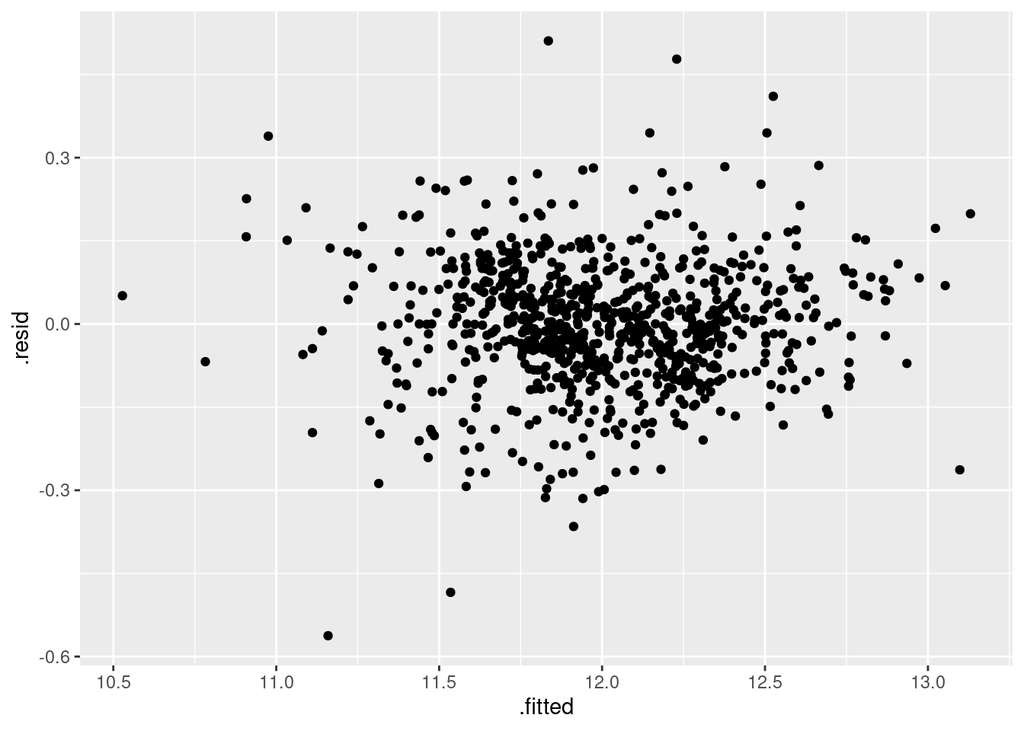

```r
ggplot(final_model, aes(x = .fitted, y = .resid)) + geom_point()
```

Plot above looks good. Residuals seem to be randomly scattered around 0 and there are no obvious patterns in the plot.

### 2.4.2 Section 4.2 Final Model RMSE

For your final model, calculate and briefly comment on the RMSE.

RMSE of the final model on the training dataset: 21297.28

RMSE of the final model on the test/out-of-sample dataset: 23508.09

RMSE of the final model on both training and out-of-sample datasets was lower then the baseline model which is great and means that the final model is better then the baseline model (based on the RMSE). The difference between training and out-of-sample RMSEs of the final model is not big so I’m not concerned about overfitting.

### 2.4.3 Section 4.3 Final Model Evaluation

What are some strengths and weaknesses of your model?

Strengths:

- RMSE on both training & test set is better than the baseline
- No immediate evidence of overfitting

Weaknesses:

- It’s a linear model. There are very likely non linear relationships I’m not capturing, that if captured by a non linear model (ie tree based models) would help with predicting house prices.

### 2.4.4 Section 4.4 Final Model Validation

Testing your final model on a separate, validation data set is a great way to determine how your model will perform in real-life practice.

You will use the “ames_validation” dataset to do some additional assessment of your final model. Discuss your findings, be sure to mention:

- What is the RMSE of your final model when applied to the validation data?
- How does this value compare to that of the training data and/or testing data?
- What percentage of the 95% predictive confidence (or credible) intervals contain the true price of the house in the validation data set?
- From this result, does your final model properly reflect uncertainty?

```r
load("ames_validation.Rdata")
```

```r
# remove non normal sales conditions
ames_validation <- ames_validation %>% filter(Sale.Condition == "Normal")

# remove "A" level from MS Zoning since that level does not exist in the train or test dataset
ames_validation <- droplevels(ames_validation[!ames_validation$MS.Zoning == "A (agr)", ])

# remove any values with "Floor" values for "Heating" since we didn't have that in the training and test sets
floor_factor <- which(ames_validation$Heating == "Floor")
ames_validation <- ames_validation[-floor_factor,]
```

```r
# RMSE Validation - Final Model
preds_validation_final <- predict(final_model, ames_validation)
conv_prices_validation_final <- exp(preds_validation_final)
sqrt(mean((ames_validation$price - conv_prices_validation_final)^2, na.rm=TRUE))
```

```
## [1] 22576.89
```

RMSE is 22576.89 which is higher then the RMSE on the training set, but lower then the RMSE on the test set. I’m pretty happy with that RMSE given that it’s on the validation set.

```r
preds_interval <- predict(final_model, ames_validation, interval = "prediction")
preds_interval <- exp(preds_interval)
coverage_validation <- mean(ames_validation$price > preds_interval[,"lwr"] & ames_validation$price < preds_interval[,"upr"], na.rm = TRUE)
coverage_validation
```

```
## [1] 0.9263158
```

93% of true values are within the 95% predictive confidence interval. Ideally that number would be 95% but 93% is close enough that I can say that model reflects uncertainty pretty well.

## 2.5 Part 5 Conclusion

Provide a brief summary of your results, and a brief discussion of what you have learned about the data and your model.

`final_model` is a decent model but it could be a lot better. One of the main limitations is the fact that I only worked with houses that got sold under a `Normal` `Sale.Condition`. I did this to avoid unusually high or unusually low prices that occur in other `Sale.Condition`s but those still happen in the real world. One way to overcome this limitation is to gather more data on those houses and build a model specifically for those `Sale.Condition`s or maybe an ensemble of models. Another major limitation is that I am using linear models. Non linear models that capture non linear relationships would likely work better.